# Bellabeat Case Study

Love Kumar

09/05/2021

[figure not shown]

## Introduction

In this case study, I will perform real world analyses for Bellabeat, a high-tech manufacturer of health-focused smart devices for women. In order to answer the key business questions of the company I would follow the steps of data analysis process i.e Ask, Prepare, Process, Analyze, Share and Act.

##### Key StakeHolders:

- Urška Sršen: Bellabeat’s cofounder and Chief Creative Officer
- Sando Mur: Mathematician and Bellabeat’s cofounder; key member of the Bellabeat executive team

## Business task

- To Analyze non Bellabeat (FitBit) smart devices data to gain insights and trends about user’s usage of the smart devices
- To give high level recommendations for marketing strategy based on the analyses done.

## Data Preparation

I was provided with a dataset of Thirty FitBit users which is publically available at https://www.kaggle.com/arashnic/fitbit

Dataset consists of 18 csv files about the activities of users like Distance covered , Total Steps , Sleep , Active Minutes . This data was collected in the period of 03/12/2016 - 05/12/2016 .

I started with " dailyActivity_merged.csv " file .

### Lets have a look at the dataset and different attributes in this file using R.

```r
fit_data<-read.csv("dailyActivity_merged.csv")
colnames(fit_data)
```

```
##  [1] "Id"                       "ActivityDate"
##  [3] "TotalSteps"               "TotalDistance"
##  [5] "TrackerDistance"          "LoggedActivitiesDistance"
##  [7] "VeryActiveDistance"       "ModeratelyActiveDistance"
##  [9] "LightActiveDistance"      "SedentaryActiveDistance"
## [11] "VeryActiveMinutes"        "FairlyActiveMinutes"
## [13] "LightlyActiveMinutes"     "SedentaryMinutes"
## [15] "Calories"
```

```r
str(fit_data)
```

```
## 'data.frame':    940 obs. of  15 variables:
##  $ Id                      : num  1.5e+09 1.5e+09 1.5e+09 1.5e+09 1.5e+09 ...
##  $ ActivityDate            : chr  "4/12/2016" "4/13/2016" "4/14/2016" "4/15/2016" ...
##  $ TotalSteps              : int  13162 10735 10460 9762 12669 9705 13019 15506 10544 9819 ...
##  $ TotalDistance           : num  8.5 6.97 6.74 6.28 8.16 ...
##  $ TrackerDistance         : num  8.5 6.97 6.74 6.28 8.16 ...
##  $ LoggedActivitiesDistance: num  0 0 0 0 0 0 0 0 0 0 ...
##  $ VeryActiveDistance      : num  1.88 1.57 2.44 2.14 2.71 ...
##  $ ModeratelyActiveDistance: num  0.55 0.69 0.4 1.26 0.41 ...
##  $ LightActiveDistance     : num  6.06 4.71 3.91 2.83 5.04 ...
##  $ SedentaryActiveDistance : num  0 0 0 0 0 0 0 0 0 0 ...
##  $ VeryActiveMinutes       : int  25 21 30 29 36 38 42 50 28 19 ...
##  $ FairlyActiveMinutes     : int  13 19 11 34 10 20 16 31 12 8 ...
##  $ LightlyActiveMinutes    : int  328 217 181 209 221 164 233 264 205 211 ...
##  $ SedentaryMinutes        : int  728 776 1218 726 773 539 1149 775 818 838 ...
##  $ Calories                : int  1985 1797 1776 1745 1863 1728 1921 2035 1786 1775 ...
```

```r
head(fit_data)
```

```
##           Id ActivityDate TotalSteps TotalDistance TrackerDistance
## 1 1503960366    4/12/2016      13162          8.50            8.50
## 2 1503960366    4/13/2016      10735          6.97            6.97
## 3 1503960366    4/14/2016      10460          6.74            6.74
## 4 1503960366    4/15/2016       9762          6.28            6.28
## 5 1503960366    4/16/2016      12669          8.16            8.16
## 6 1503960366    4/17/2016       9705          6.48            6.48
##   LoggedActivitiesDistance VeryActiveDistance ModeratelyActiveDistance
## 1                        0               1.88                     0.55
## 2                        0               1.57                     0.69
## 3                        0               2.44                     0.40
## 4                        0               2.14                     1.26
## 5                        0               2.71                     0.41
## 6                        0               3.19                     0.78
##   LightActiveDistance SedentaryActiveDistance VeryActiveMinutes
## 1                6.06                       0                25
## 2                4.71                       0                21
## 3                3.91                       0                30
## 4                2.83                       0                29
## 5                5.04                       0                36
## 6                2.51                       0                38
##   FairlyActiveMinutes LightlyActiveMinutes SedentaryMinutes Calories
## 1                  13                  328              728     1985
## 2                  19                  217              776     1797
## 3                  11                  181             1218     1776
## 4                  34                  209              726     1745
## 5                  10                  221              773     1863
## 6                  20                  164              539     1728
```

## Data Cleaning and Manipulation

For data cleaning and manipulation I use spreadsheet software (Google sheets)

### data cleaning procedure

- Changed the format of specific columns to have only 2 decimal points in observations
- Filtered the data to find rows with all zeros observations.
- Deleted the rows with all zeros obsevations .
- Deleted the blanks rows .

### data manipulation

There are atrributes named TotalDistance,LightActiveDistance,ModeratelyActiveDistance and VeryActiveDistance

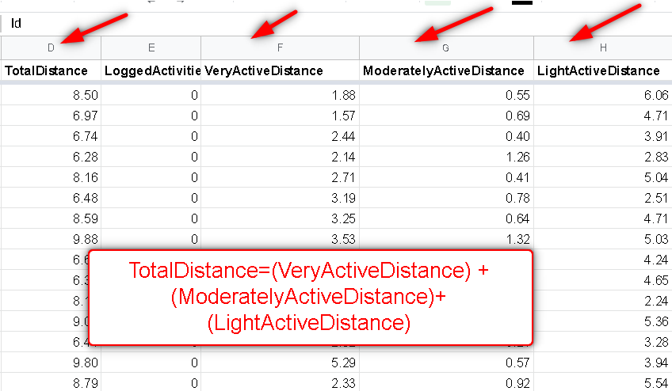

##### I Created Calculated Fields that contains percentage values of LightActiveDistance , ModeratelyActiveDistance And VeryActiveDistance over the TotalDistance covered

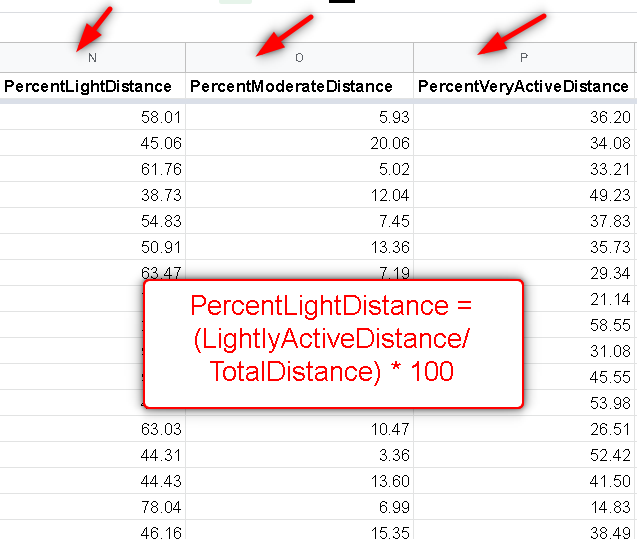

Calculated percentages

##### I calculated Total Active Minutes by adding the columns named VeryActiveMinutes ,fairlyActiveMinutes and LightlyActiveMinutes

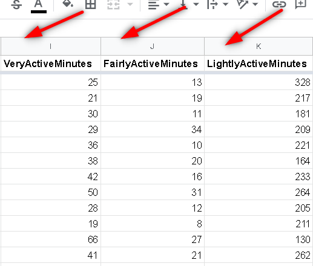

##### Then I created a column containing Percentage values of LightlyActiveMinutes and VeryActiveMinutes as follows

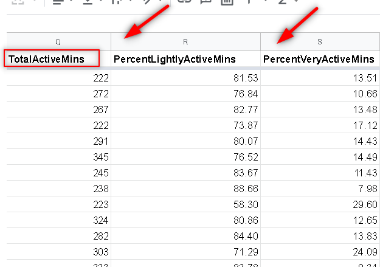

[figure not shown]

## Analyses and Visualizations

###### Installing Tidyverse package and loading ggplot

```r
install.packages("tidyverse",repos = "http://cran.us.r-project.org")
```

```r
library(ggplot2)
```

### Analysis and visualizations based on Distance covered :

- Using Cleaned version of “dailyActivity_merged.csv”

#### Total Distance Vs Overall Calories Burnt

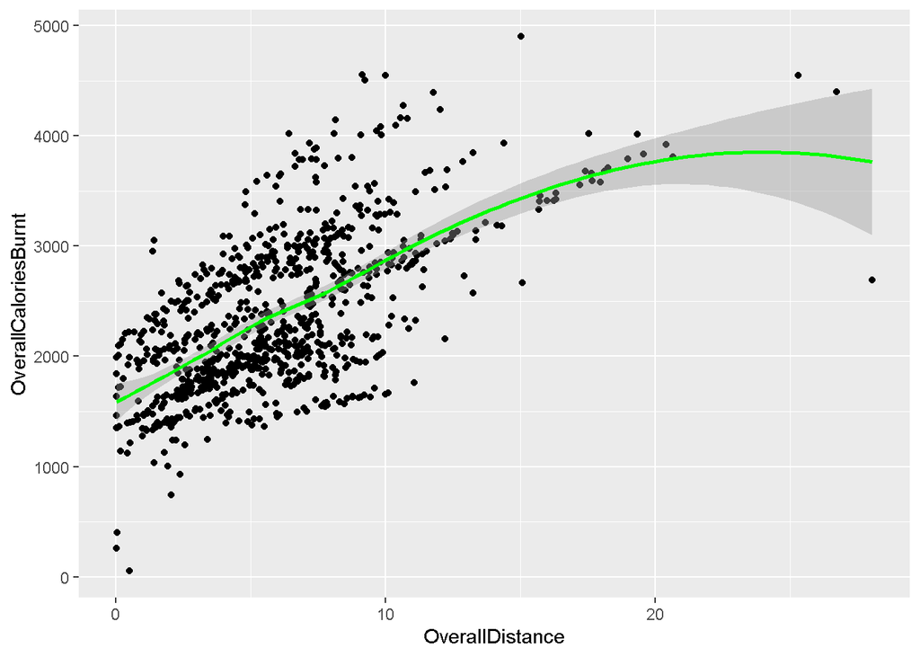

```r
fit<-read.csv("dailyActivity_merged_cleaned.csv")
ggplot(data=fit)+geom_point(mapping = aes(x=TotalDistance,y=Calories))+
  geom_smooth(mapping = aes(x=TotalDistance,y=Calories),color="green")+
  xlab("OverallDistance")+ylab("OverallCaloriesBurnt")
```

##### It clearly shows a positive correlation between Total Distance and Calories Burnt . Hence there is a upward Trendline . But! Lets dive deeper , and have a look at

### Percentage of Lightly Active distance Vs Total Calories Burnt

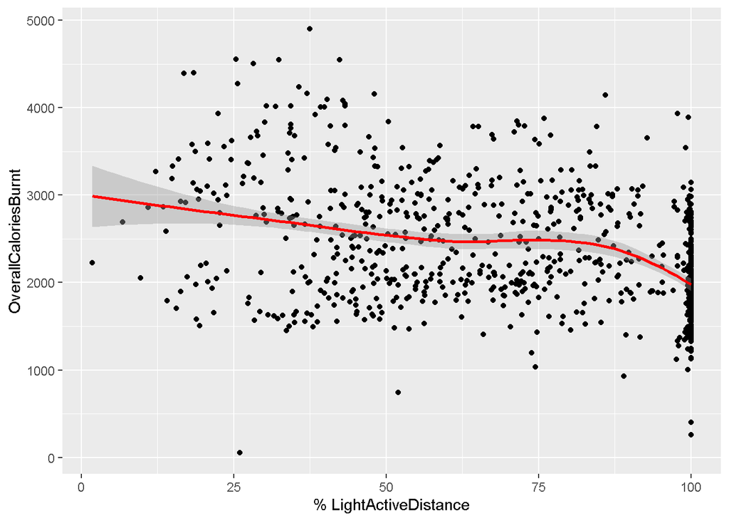

```r
ggplot(data=fit)+geom_point(mapping = aes(x=PercentLightDistance,y=Calories))+
  geom_smooth(mapping = aes(x=PercentLightDistance,y=Calories),color="red")+
  xlab("% LightActiveDistance")+ylab("OverallCaloriesBurnt")
```

##### This shows that more the percentage of lightly active covered distance in total distance covered lesser the overall calories burnt. There is a declining trendline.

##On the Other Hand

### Percentageof very active dictance Vs Total Calories Burnt

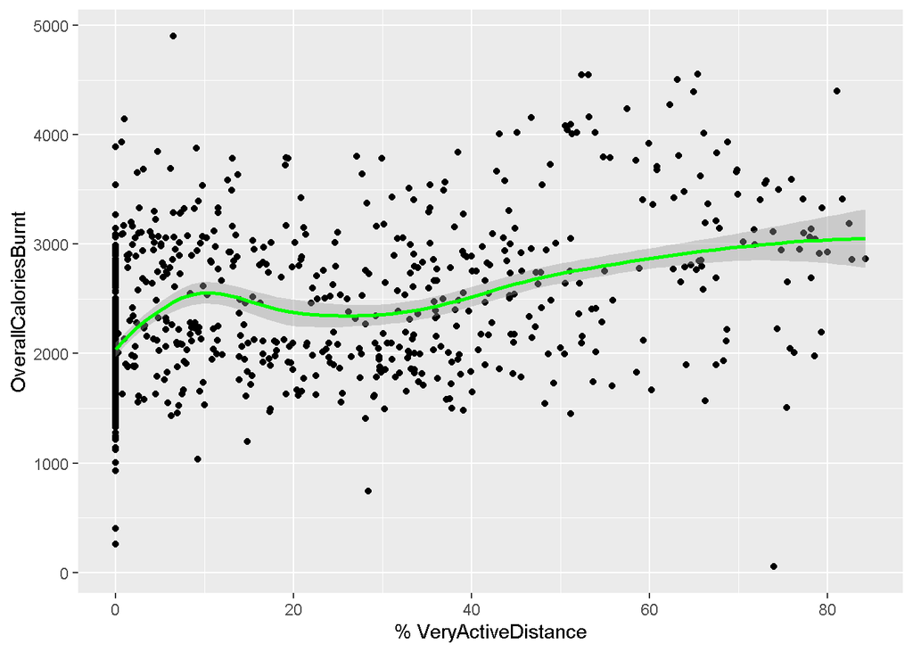

```r
ggplot(data=fit)+geom_point(mapping = aes(x=PercentVeryActiveDistance,y=Calories))+
  geom_smooth(mapping = aes(x=PercentVeryActiveDistance,y=Calories),color="green")+
  xlab("% VeryActiveDistance")+ylab("OverallCaloriesBurnt")
```

##### This Clearly Shows that more the percentage of very actively covered distance in total distance covered more the overall calories burnt

### Analysis and visualizations based on Total Steps Taken :

#### Total Steps Vs Overall Calories Burnt

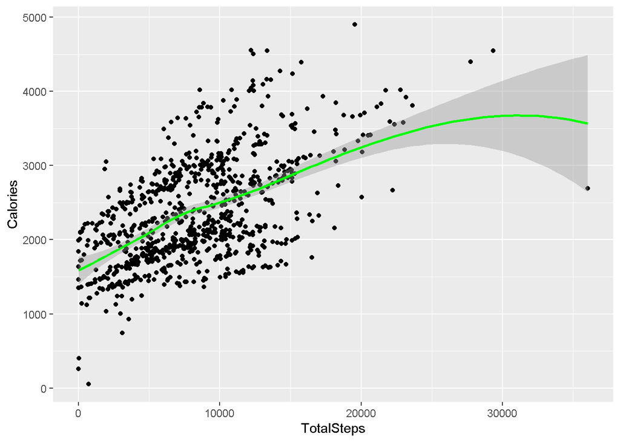

```r
library(ggplot2)
ggplot(data=fit)+
  geom_point(mapping = aes(x=TotalSteps,Calories))+
  geom_smooth(mapping = aes(x=TotalSteps,Calories),color="green")
```

##### It is clear that more steps burns more calories . But According to the data , 64.8 % of the observations are less than 10k steps .

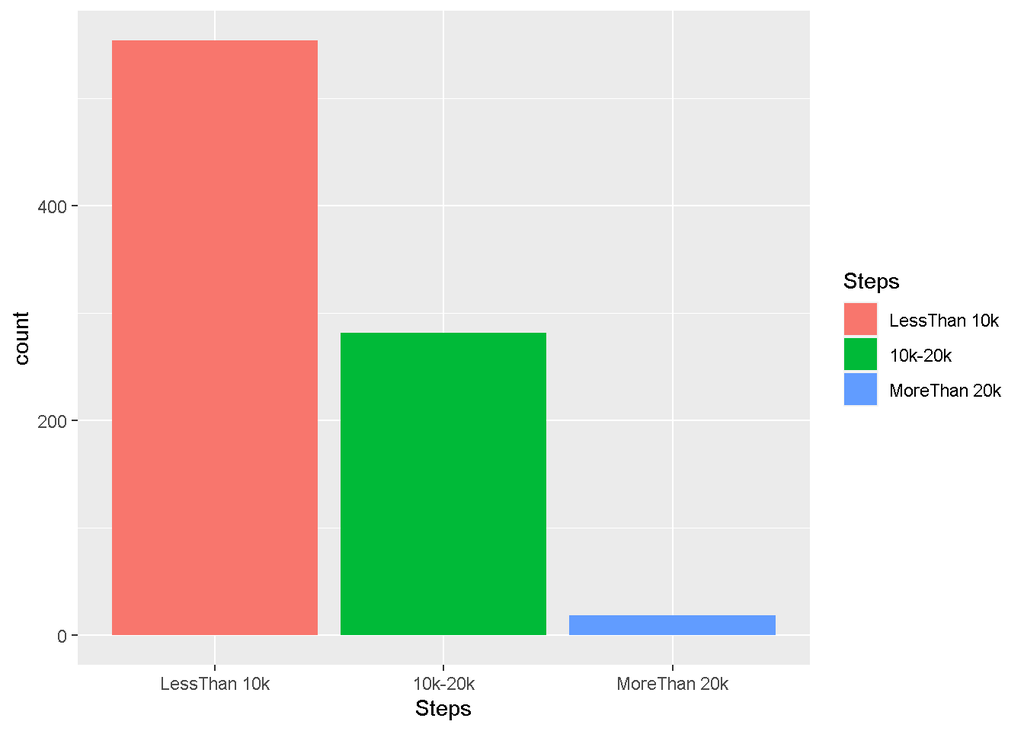

```r
fit$Steps<-fit$TotalSteps
fit$Steps<-cut(fit$Steps,breaks = c(0,9999,19999,37000),labels = c("LessThan 10k","10k-20k","MoreThan 20k"))
ggplot(data=fit)+geom_bar(mapping = aes(x=Steps,fill=Steps))
```

### Analysis based on Active Minutes

##### It is obvious that more the total active minutes in a day more the overall calories burnt

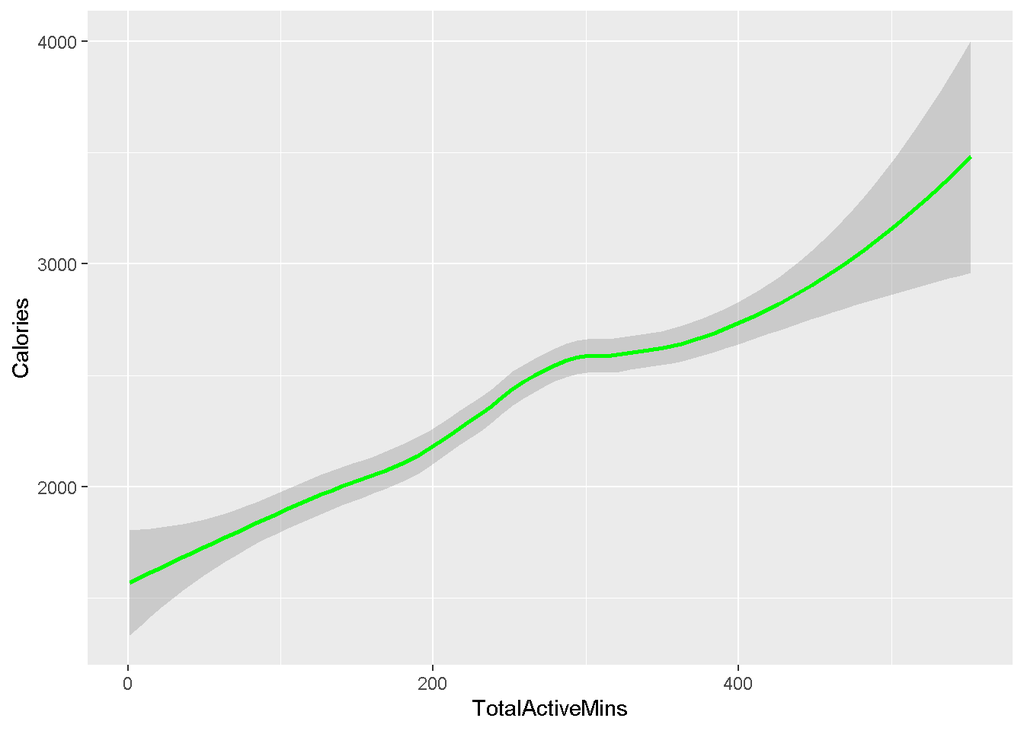

```r
ggplot(data=fit)+geom_smooth(mapping = aes(x=TotalActiveMins,y=Calories),color="green")
```

##### But these active minutes can be Lightly Active Minutes or Very Active Minutes. Lets see , how the percentage values Very Active Minutes is Related to the overall Calories burnt

#### Percentage of Very Active Minutes Vs Calories Burnt

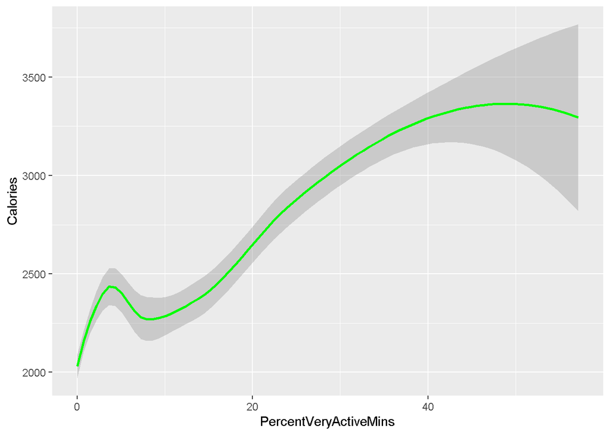

```r
ggplot(data=fit)+
  geom_smooth(mapping = aes(x=PercentVeryActiveMins,y=Calories),color="green")
```

##### More the percentage of Very Active Minutes in total active minutes , more the overall calories burnt . But In the data Most of the Oservations have very less “Very Active Minutes”

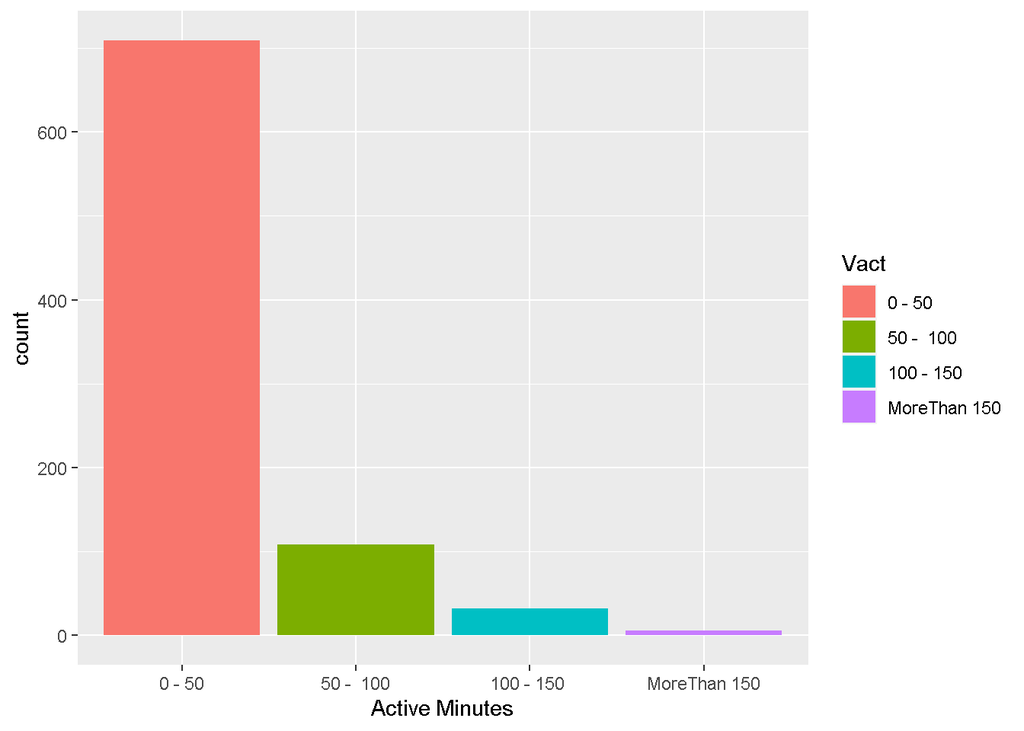

```r
fit$Vact<-fit$VeryActiveMinutes
fit$Vact<-cut(fit$Vact,breaks = c(-1,50,100,150,250),labels = c("0 - 50","50 -  100","100 - 150 ","MoreThan 150"))
ggplot(data = fit)+geom_bar(mapping = aes(x=Vact,fill=Vact))+xlab("Active Minutes")
```

### Analysis on Sleep

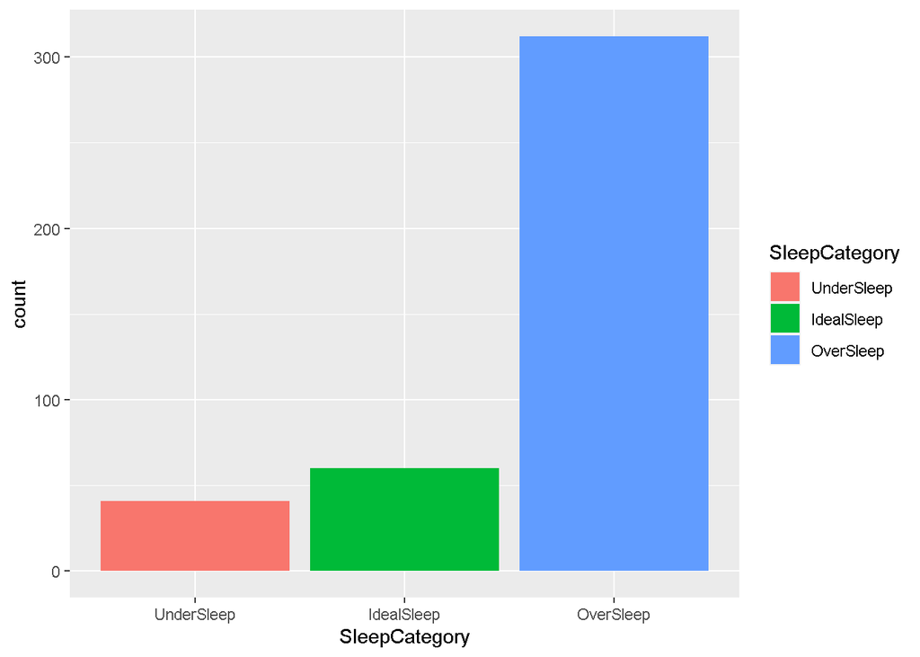

```r
sleep<-read.csv("sleepDay_merged.csv")
sleep$SleepCategory<-sleep$TotalHoursAsleep
sleep$SleepCategory<-cut(sleep$SleepCategory,breaks = c(1,7,9,20),labels = c("UnderSleep","IdealSleep","OverSleep"))
ggplot(data=sleep)+geom_bar(mapping = aes(x=SleepCategory,fill=SleepCategory))
```

## Some recommendations based on above analyses :

- Add and advertise a feature that give daily targets of steps to take to the users . (increase the target weekly by some some steps)
- Add and advertise a feature that challenge the users to walk faster while the users are walking .
- Add and advertise a feature that categorize the user based on their sleep hours and motivates them to fall under “Ideal Sleeper” category.